# Math389 Final Project

Tongzhou Wang, Finnegan Hu

4/21/2019

## Introduction to the Dataset

We chose Caltech-UCSD Birds-200-2011 to be our dataset. This dataset contains 200 birds species and there are roughly 60 images for each species. Other than different species, our dataset also catagorizes images by part location annotations. These birds are mainly from Northen America and many similarities exist for various species.

We want to utilize this dataset to develop a model to identify input image’s species. Here we take the first 50 classes, using 60% of the data to train our model and the other 40% for validation.

There are also some properties of the dataset that might pose difficulty for the model. Firstly, some species are really alike to each other. For example, the Parakeet Auklet and Rhinoceros Auklet are pretty similar. They both have black head and back. Near to their eyes, they both have a slash of white feathers. Another problem may be varied backgrounds for the same species. Because of this, the model should depends more on birds themselves.

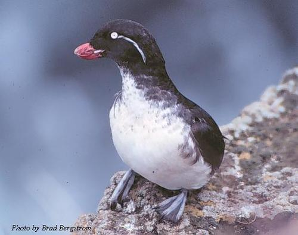

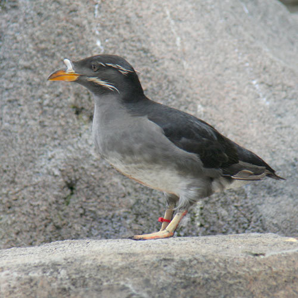

## Data Embedding

We embeded the data using keras pretrained `resnet50` model, taking from the `ave_pool` layer. We also tried to embed with `vgg19` and `inception_v3`, also taking from the ave_pool layer. However, in a simple nueral network model built on the embeded data, the accuracy rate does not seem to improve after a lot of iterations, so we decided to go with `resnet50`. The embeded data is a matrix of numbers with 2889 rows (number of data entries) and 2048 columns (number of features for each data entry).

## Neural Network Model

For our neural network model, we have 4 dense layers, each with 512 hidden neurons and `relu` activation function. We also applied `glorot_normal` as our kernel initializer and added layer dropout for each layer with rate of 0.25. For our optimizer, we used stochastic gradient decent with learning rate of 0.0025 and momentum of 0.75.

```
## Model
## ___________________________________________________________________________
## Layer (type)                     Output Shape                  Param #
## ===========================================================================
## dense_1 (Dense)                  (None, 512)                   1049088
## ___________________________________________________________________________
## activation_1 (Activation)        (None, 512)                   0
## ___________________________________________________________________________
## dropout_1 (Dropout)              (None, 512)                   0
## ___________________________________________________________________________
## dense_2 (Dense)                  (None, 512)                   262656
## ___________________________________________________________________________
## activation_2 (Activation)        (None, 512)                   0
## ___________________________________________________________________________
## dropout_2 (Dropout)              (None, 512)                   0
## ___________________________________________________________________________
## dense_3 (Dense)                  (None, 512)                   262656
## ___________________________________________________________________________
## activation_3 (Activation)        (None, 512)                   0
## ___________________________________________________________________________
## dropout_3 (Dropout)              (None, 512)                   0
## ___________________________________________________________________________
## dense_4 (Dense)                  (None, 512)                   262656
## ___________________________________________________________________________
## activation_4 (Activation)        (None, 512)                   0
## ___________________________________________________________________________
## dropout_4 (Dropout)              (None, 512)                   0
## ___________________________________________________________________________
## dense_5 (Dense)                  (None, 50)                    25650
## ___________________________________________________________________________
## activation_5 (Activation)        (None, 50)                    0
## ===========================================================================
## Total params: 1,862,706
## Trainable params: 1,862,706
## Non-trainable params: 0
## ___________________________________________________________________________
```

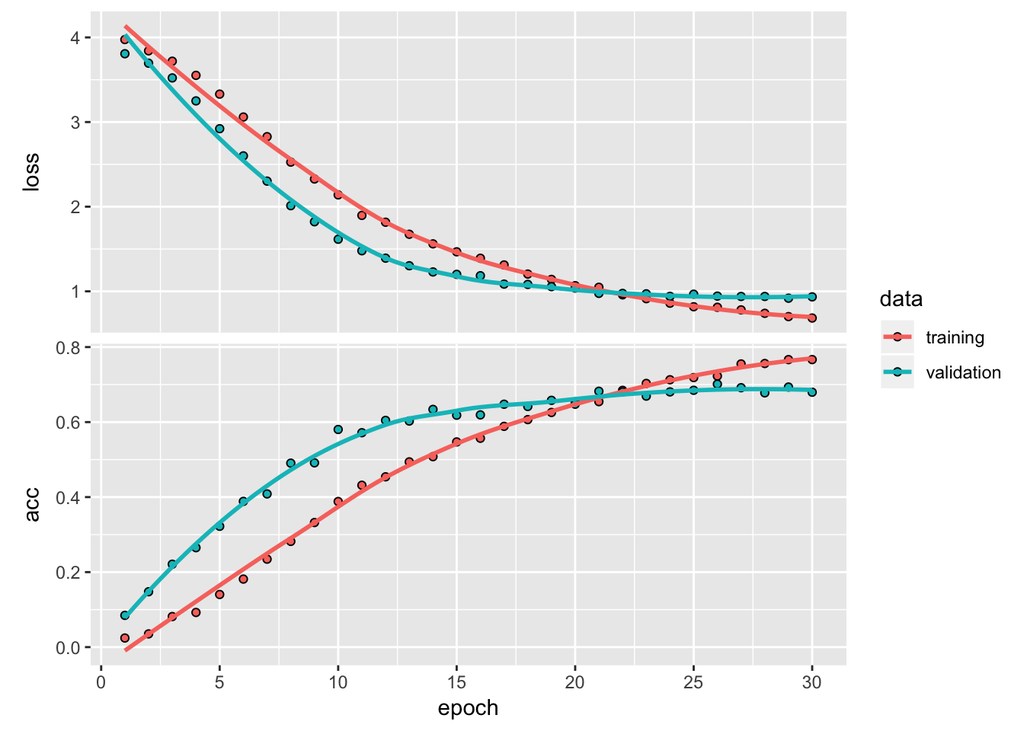

```
##     train     valid
## 0.9156557 0.6796200
```

After 30 epochs, the model we obtained gives reasonably well predictions. Since there are 50 classes in total, the correct rate of random guessing should be 0.02. We can also see from the plot above that even though there is an overfit on training data, the model predicts better on validation set until over 20 epochs.

We also built a gradient boosted tree model with the embeded data. Even though the performance is not much worse than that with neural network model, it is more overfit and takes significantly longer time to train.

```
## Multiple eval metrics are present. Will use valid_merror for early stopping.
## Will train until valid_merror hasn't improved in 50 rounds.
##
```

```
##     train     valid
## 1.0000000 0.6303972
```

## Misclassification Analysis

```
##     0  1  2  3  4  5  6  7  8  9 10 11 12 13 14 15 16 17 18 19 20 21 22 23
## 0  36  0  0  0  0  0  0  0  0  0  0  0  0  0  0  0  0  0  0  0  0  0  0  0
## 1   0 36  0  0  0  0  0  0  0  0  0  0  0  0  0  0  0  0  0  0  0  0  0  0
## 2   0  0 35  0  0  0  0  0  0  0  0  0  0  0  0  0  0  0  0  0  0  0  0  0
## 3   0  0  0 36  0  0  0  0  0  0  0  0  0  0  0  0  0  0  0  0  0  0  0  0
## 4   0  0  0  0 26  0  0  0  0  0  0  0  0  0  0  0  0  0  0  0  0  0  0  0
## 5   0  0  0  0  0 25  0  0  0  0  0  0  0  0  0  0  0  0  0  0  0  0  0  0
## 6   0  0  0  0  0  0 32  0  0  0  0  0  0  0  0  0  0  0  0  0  0  0  0  0
## 7   0  0  0  0  0  0  0 29  0  0  0  0  0  0  0  0  0  0  0  0  0  0  0  0
## 8   0  0  0  0  0  0  0  0 35  0  0  0  0  0  0  0  0  0  0  0  0  0  0  0
## 9   0  0  0  0  0  0  0  0  0 36  0  0  0  0  0  0  0  0  0  0  0  0  0  0
## 10  0  0  0  0  0  0  0  0  0  0 36  0  0  0  0  0  0  0  0  0  0  0  0  0
## 11  0  0  0  0  0  0  0  0  0  0  0 34  0  0  0  0  0  0  0  0  0  0  0  0
## 12  0  0  0  0  0  0  0  0  0  0  0  0 36  0  0  0  0  0  0  0  0  0  0  0
## 13  0  0  0  0  0  0  0  0  0  0  0  0  0 36  0  0  0  0  0  0  0  0  0  0
```

[output cut: 138 more lines]

Our model does give a fairly accurate prediction on the dataset, but there are some classes that seem to be harder to distinguish. For example, images of class 38 are misclassified as class 36 7 times.

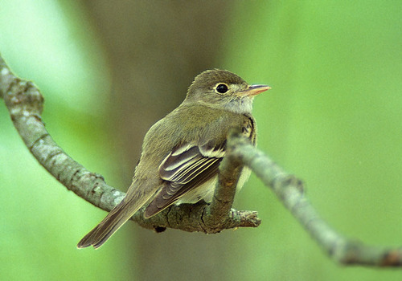

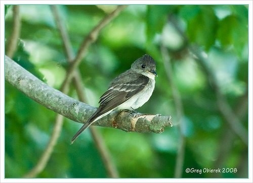

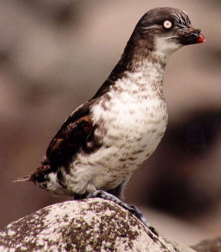

[figure not shown]

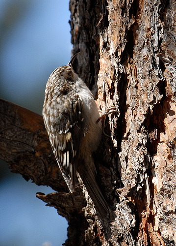

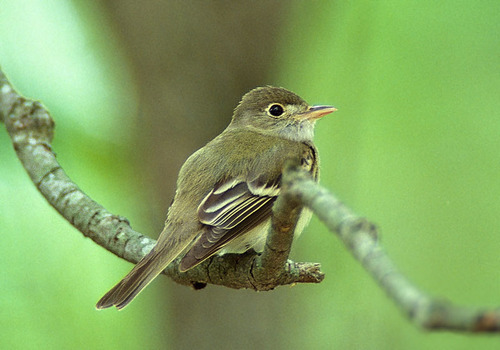

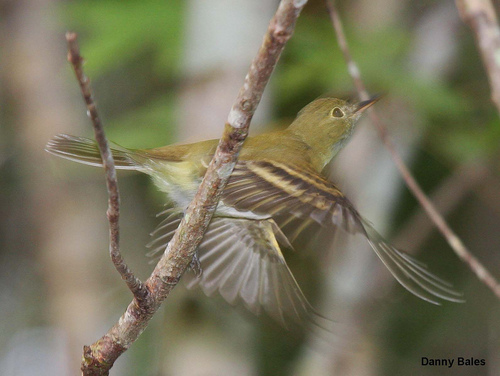

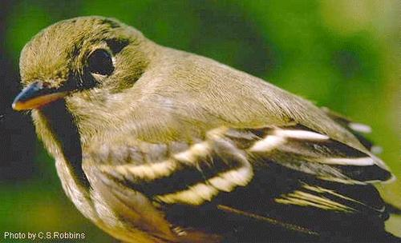

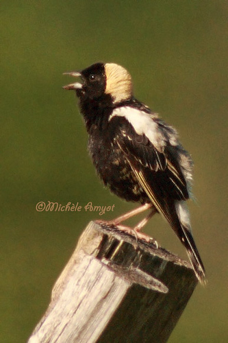

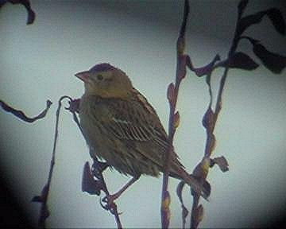

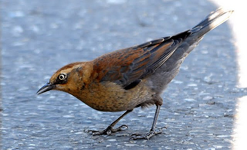

## Embedding Visualizations

The points in the visualization of PCA are quite dense in some areas, but we can observe clusterings of the same class especially on the edges.

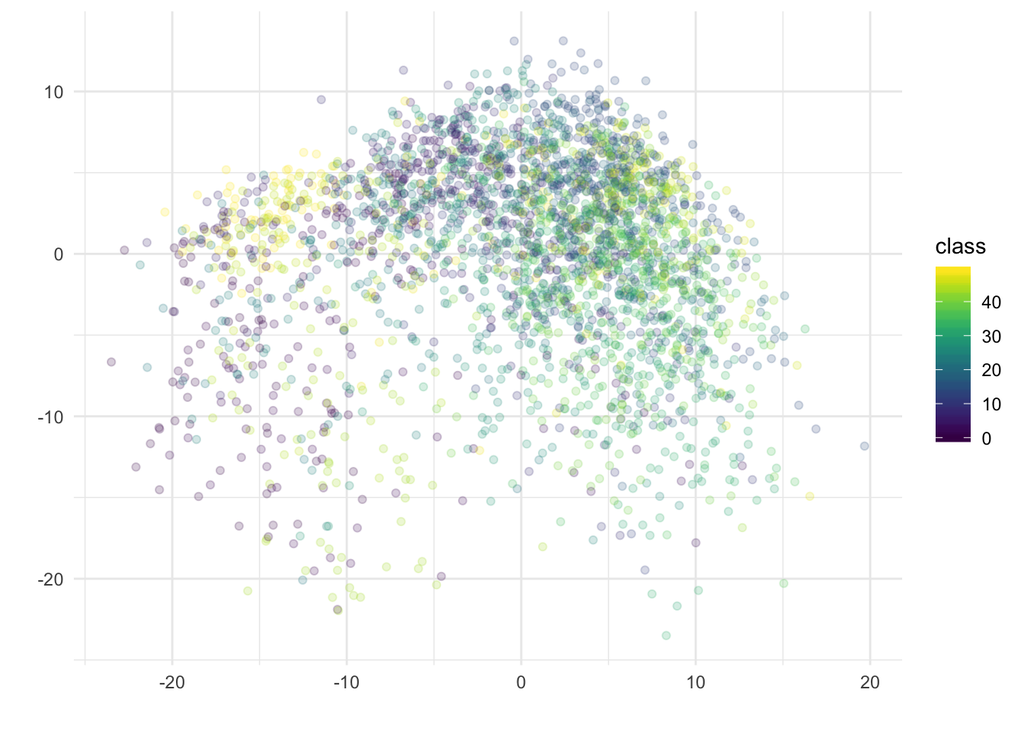

The visualization of t-SNE analysis shows more clear evidence of clusterings of the same class.

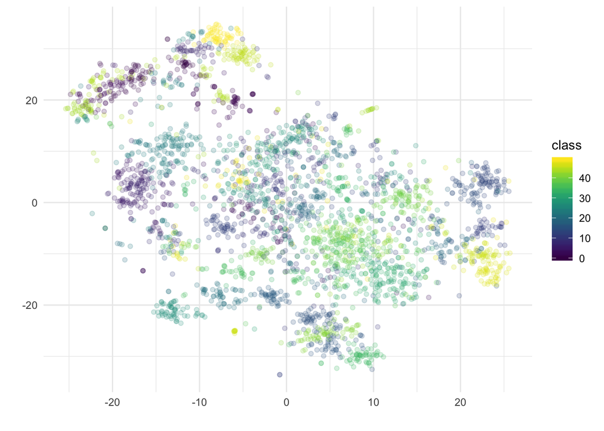